# Spatial Autocorrelation

Orlando Sabogal-Cardona

Summer 2023

# 1 Libraries and raw data

```r
library(tidyverse)
library(magrittr)
library(sf)
library(tmap)

library(spdep) # Spatial weights
```

```r
load("../03_MexicoCity_HTS/Mexico_HTS.RData")
ls()
```

```
[1] "BB_Districts"             "Centroids_MexicoCity_HTS" "KNN"
[4] "MexicoCity_Fringe"        "MexicoCity_HTS"           "Neigh_"
[7] "Neigh_Centroids"          "WM_"                      "WM_Centroids"
```

The following would be the alternative:

```r
# MexicoCity_HTS_Database <- read_delim("../03_MexicoCity_HTS/MexicoCity_HTS_Database.csv",
#                                       delim = ";")
# MexicoCity_Districts <- st_read("../03_MexicoCity_HTS/MexicoCity_Districts.shp")
#
#
# MexicoCity_HTS <- MexicoCity_Districts %>%
#   left_join(MexicoCity_HTS_Database)
```

# 2 Neighbours

## 2.1 With polygons

from the *“spdep”* we will use the following functions:

- **poly2nb()**: to get a neighbours list based contiguous boundaries
- **nb2listw()**: to get the spatial weights

```r
Neigh_ <- poly2nb(MexicoCity_HTS) # arugment queen = TRUE
WM_ <- nb2listw(Neigh_, style = "W")
# see https://r-spatial.github.io/spdep/reference/nb2listw.html for the style argument
```

```r
class(Neigh_)
```

```
[1] "nb"
```

```r
Neigh_
```

```
Neighbour list object:
Number of regions: 194
Number of nonzero links: 1032
Percentage nonzero weights: 2.742055
Average number of links: 5.319588
```

```r
dim(MexicoCity_HTS)
```

```
[1] 194  58
```

```r
length(Neigh_)
```

```
[1] 194
```

```r
Neigh_[1]
```

```
[[1]]
[1] 2 3 4 7 8
```

```r
Neigh_[5]
```

```
[[1]]
[1]  4 32 33
```

Important: Check this results with QGIS

## 2.2 With points

from the *“spdep”* we will use the following functions:

- **knearneigh()**: K nearest neighbours for spatial weights
- **knn2nb()**: Converts output from knearneigh() to a neighbours list of class nb
- **nb2listw()**: to get the spatial weights

```r
Centroids_MexicoCity_HTS <- st_centroid(MexicoCity_HTS) %>% st_geometry()
```

The knearneigh() function returns an intermediate form converted to an nb object by knn2nb(); knearneigh() can also take a longlat= argument to handle geographical coordinates

```r
st_is_longlat(Centroids_MexicoCity_HTS)
```

```
[1] TRUE
```

```r
KNN <- knearneigh(Centroids_MexicoCity_HTS,  k = 6) # longlat = NULL
Neigh_Centroids <- knn2nb(KNN)
WM_Centroids <- nb2listw(Neigh_Centroids, style = "W")
```

```r
class(Neigh_)
```

```
[1] "nb"
```

```r
class(Neigh_Centroids)
```

```
[1] "nb"
```

```r
class(Neigh_) == class(Neigh_Centroids)
```

```
[1] TRUE
```

```r
class(WM_)
```

```
[1] "listw" "nb"
```

```r
class(WM_Centroids)
```

```
[1] "listw" "nb"
```

```r
class(WM_) == class(WM_Centroids)
```

```
[1] TRUE TRUE
```

```r
Neigh_Centroids[1]
```

```
[[1]]
[1] 2 3 4 5 6 7
```

```r
Neigh_Centroids[5]
```

```
[[1]]
[1]  4  6 32 33 34 36
```

```r
KNN
```

```
$nn
       [,1] [,2] [,3] [,4] [,5] [,6]
  [1,]    2    3    4    5    6    7
  [2,]    1    3    7    8   16   21
  [3,]    1    2    4   21   28   32
  [4,]    1    3    5    6    7   32
  [5,]    4    6   32   33   34   36
  [6,]    1    4    5    7   11   12
  [7,]    1    2    6    8   10   11
  [8,]    1    2    7    9   10   16
  [9,]    7    8   10   14   15   55
 [10,]    7    8    9   11   13   14
 [11,]    6    7   10   12   13   14
 [12,]    6   11   13   36   37   38
 [13,]   10   11   12   14   40   46
```

[output cut: 365 more lines]

# 3 Spatial Autocorrelation

## 3.1 Preliminary exploration

We want to explore car-based trips. Should we analyze the total count? the share of total trips? or trips per inhabitants?

```r
summary(MexicoCity_HTS$Trips_Automovil)
```

```
   Min. 1st Qu.  Median    Mean 3rd Qu.    Max.
  110.0   300.8   438.0   540.9   642.8  2490.0
```

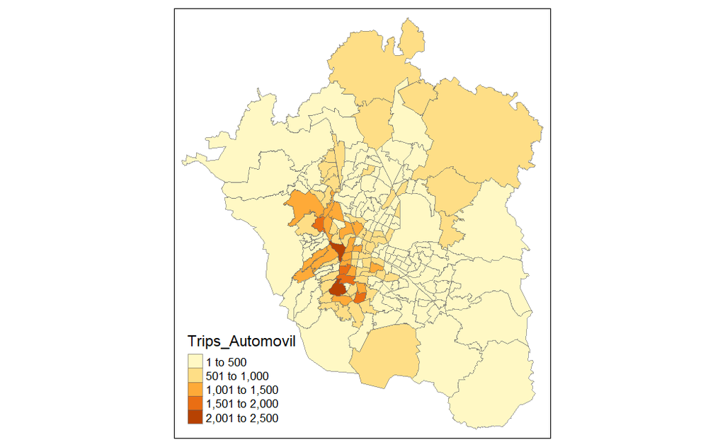

```r
tm_shape(MexicoCity_HTS) +
  tm_fill("Trips_Automovil") +
  tm_borders(alpha = 0.6)
```

```r
MexicoCity_HTS %<>%
  mutate(CarTrips_Proportion = Trips_Automovil/TotalTrips,
         CarTrips_PerPopulation = Trips_Automovil/TotalPeople)
```

```r
summary(MexicoCity_HTS$Trips_Automovil)
```

```
   Min. 1st Qu.  Median    Mean 3rd Qu.    Max.
  110.0   300.8   438.0   540.9   642.8  2490.0
```

```r
summary(MexicoCity_HTS$CarTrips_Proportion)
```

```
   Min. 1st Qu.  Median    Mean 3rd Qu.    Max.
0.03783 0.08574 0.11236 0.12337 0.15241 0.41726
```

```r
summary(MexicoCity_HTS$CarTrips_PerPopulation)
```

```
   Min. 1st Qu.  Median    Mean 3rd Qu.    Max.    NA's
 0.1008  0.2905  0.4219  0.5658  0.6500  3.8485       1
```

Why do we have an NA?

```r
summary(MexicoCity_HTS$TotalPeople)
```

```
   Min. 1st Qu.  Median    Mean 3rd Qu.    Max.    NA's
    634     968    1035    1027    1103    1333       1
```

```r
MexicoCity_HTS %>% filter(is.na(TotalPeople)) %>% select(Distrito)
```

```
Simple feature collection with 1 feature and 1 field
Geometry type: MULTIPOLYGON
Dimension:     XY
Bounding box:  xmin: -99.09278 ymin: 19.41697 xmax: -99.04731 ymax: 19.45018
Geodetic CRS:  WGS 84
  Distrito                       geometry
1      034 MULTIPOLYGON (((-99.08461 1...
```

```r
# View(MexicoCity_HTS %>% select(Distrito, TotalPeople))
```

```r
MexicoCity_HTS %<>% replace_na(list(TotalPeople = 120)) # Any take on this?

MexicoCity_HTS %<>%
  mutate(CarTrips_Proportion = Trips_Automovil/TotalTrips,
         CarTrips_PerPopulation = Trips_Automovil/TotalPeople)
```

```r
summary(MexicoCity_HTS$Trips_Automovil)
```

```
   Min. 1st Qu.  Median    Mean 3rd Qu.    Max.
  110.0   300.8   438.0   540.9   642.8  2490.0
```

```r
summary(MexicoCity_HTS$CarTrips_Proportion)
```

```
   Min. 1st Qu.  Median    Mean 3rd Qu.    Max.
0.03783 0.08574 0.11236 0.12337 0.15241 0.41726
```

```r
summary(MexicoCity_HTS$CarTrips_PerPopulation)
```

```
   Min. 1st Qu.  Median    Mean 3rd Qu.    Max.
 0.1008  0.2916  0.4249  0.5680  0.6554  3.8485
```

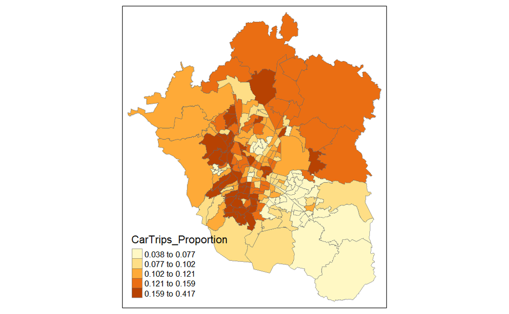

```r
tm_shape(MexicoCity_HTS) +
  tm_fill("CarTrips_Proportion", style = "quantile") +
  tm_borders(alpha = 0.6)
```

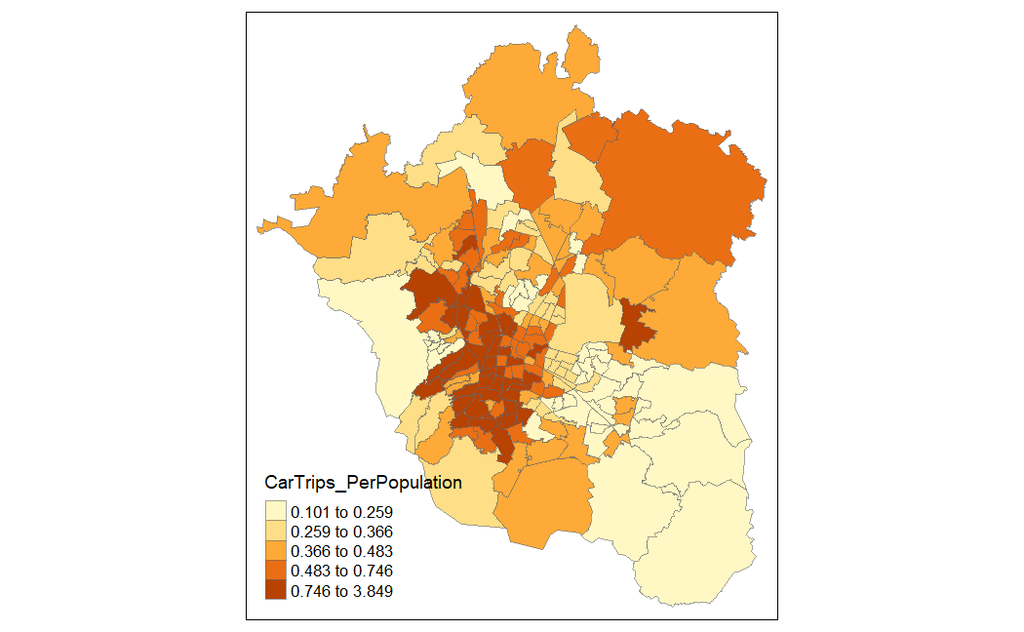

```r
tm_shape(MexicoCity_HTS) +
  tm_fill("CarTrips_PerPopulation", style = "quantile") +
  tm_borders(alpha = 0.6)
```

### 3.1.1 Ok, let’s fix that map

```r
BB_Districts <- st_bbox(MexicoCity_HTS)
BB_Districts[1] <- -99.8
BB_Districts
```

```
     xmin      ymin      xmax      ymax
-99.80000  18.93534 -98.59687  20.06826
```

```r
MexicoCity_Fringe <- st_read("../03_MexicoCity_HTS/UrbanFringe_MexicoCity.shp")
```

```r
st_crs(MexicoCity_HTS) == st_crs(MexicoCity_Fringe)
```

```
[1] TRUE
```

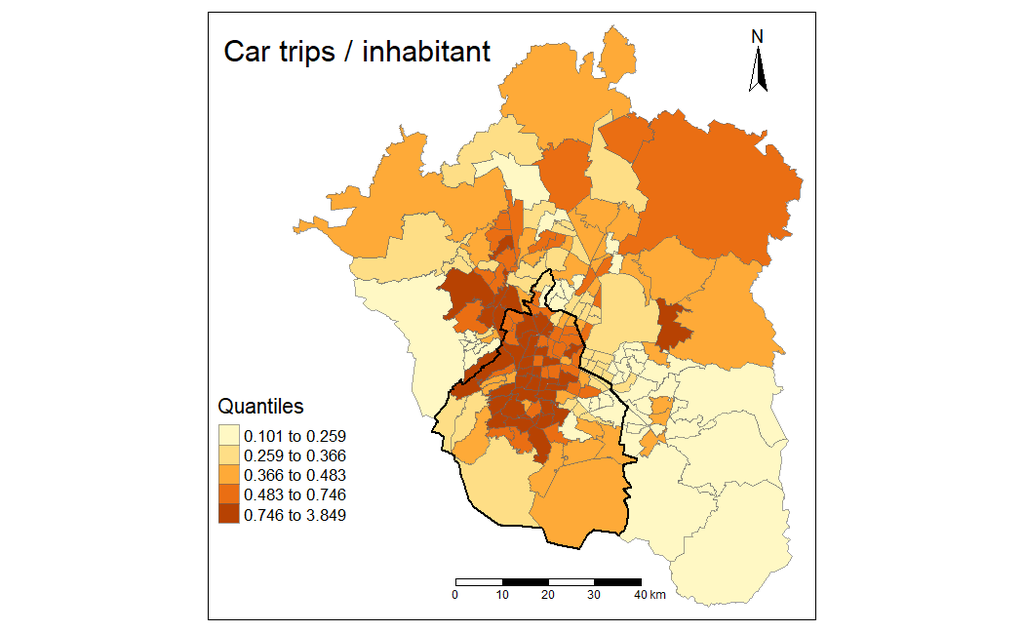

```r
tm_shape(MexicoCity_HTS, bbox = BB_Districts) +
  tm_fill("CarTrips_PerPopulation", style = "quantile", title = "Quantiles") +
  tm_borders(alpha = 0.6) +
  tm_shape(MexicoCity_Fringe) +
  tm_polygons(alpha = 0, border.col = "black", lwd = 1.4, lty = "solid") +
  tm_compass(size = 2, type = "arrow", position = c(0.85,0.87)) +
  tm_scale_bar(position = c(0.4,0.02)) +
  tm_layout(title = "Car trips / inhabitant", legend.position = c(0.01,0.15), scale = 1)
```

## 3.2 Moran’s I

We can use the two following functions from the *spdep* library:

- **moran.test()**: Analytical method. From the spdep
- **moran.mc()**: Montecarlo based method

```r
moran.test(MexicoCity_HTS$Trips_Automovil, WM_)
```

```
    Moran I test under randomisation

data:  MexicoCity_HTS$Trips_Automovil
weights: WM_

Moran I statistic standard deviate = 10.616, p-value < 2.2e-16
alternative hypothesis: greater
sample estimates:
Moran I statistic       Expectation          Variance
      0.459283602      -0.005181347       0.001914295
```

```r
moran.test(MexicoCity_HTS$CarTrips_Proportion, WM_)
```

```
    Moran I test under randomisation

data:  MexicoCity_HTS$CarTrips_Proportion
weights: WM_

Moran I statistic standard deviate = 11.238, p-value < 2.2e-16
alternative hypothesis: greater
sample estimates:
Moran I statistic       Expectation          Variance
      0.487662076      -0.005181347       0.001923353
```

```r
moran.test(MexicoCity_HTS$CarTrips_Proportion, WM_)
```

```
    Moran I test under randomisation

data:  MexicoCity_HTS$CarTrips_Proportion
weights: WM_

Moran I statistic standard deviate = 11.238, p-value < 2.2e-16
alternative hypothesis: greater
sample estimates:
Moran I statistic       Expectation          Variance
      0.487662076      -0.005181347       0.001923353
```

```r
moran.mc(MexicoCity_HTS$Trips_Automovil, WM_, nsim = 1000)
```

```
    Monte-Carlo simulation of Moran I

data:  MexicoCity_HTS$Trips_Automovil
weights: WM_
number of simulations + 1: 1001

statistic = 0.45928, observed rank = 1001, p-value = 0.000999
alternative hypothesis: greater
```

```r
moran.mc(MexicoCity_HTS$CarTrips_Proportion, WM_, nsim = 1000)
```

```
    Monte-Carlo simulation of Moran I

data:  MexicoCity_HTS$CarTrips_Proportion
weights: WM_
number of simulations + 1: 1001

statistic = 0.48766, observed rank = 1001, p-value = 0.000999
alternative hypothesis: greater
```

```r
moran.mc(MexicoCity_HTS$CarTrips_PerPopulation, WM_, nsim = 1000)
```

```
    Monte-Carlo simulation of Moran I

data:  MexicoCity_HTS$CarTrips_PerPopulation
weights: WM_
number of simulations + 1: 1001

statistic = 0.4752, observed rank = 1001, p-value = 0.000999
alternative hypothesis: greater
```

## 3.3 Moran’s I: the regression way

```r
DataTemp <- data.frame(
  Lagged = Variable.lag,
  Value = ZonesData$Variable)
```

```
Error in data.frame(Lagged = Variable.lag, Value = ZonesData$Variable) :
  object 'ZonesData' not found
```

```r
summary(Model_Y_Ylagged)
```

```
Call:
lm(formula = Lagged ~ Value, data = DataTemp)

Residuals:
     Min       1Q   Median       3Q      Max
-1.01239 -0.15256 -0.05003  0.07945  0.99587

Coefficients:
            Estimate Std. Error t value Pr(>|t|)
(Intercept)  0.31404    0.02855   11.00   <2e-16 ***
Value        0.47520    0.03846   12.36   <2e-16 ***
---
Signif. codes:  0 ‘***’ 0.001 ‘**’ 0.01 ‘*’ 0.05 ‘.’ 0.1 ‘ ’ 1

Residual standard error: 0.2559 on 192 degrees of freedom
Multiple R-squared:  0.4429,    Adjusted R-squared:   0.44
F-statistic: 152.7 on 1 and 192 DF,  p-value: < 2.2e-16
```

```r
coef(Model_Y_Ylagged)[2]
```

```
    Value
0.4751972
```

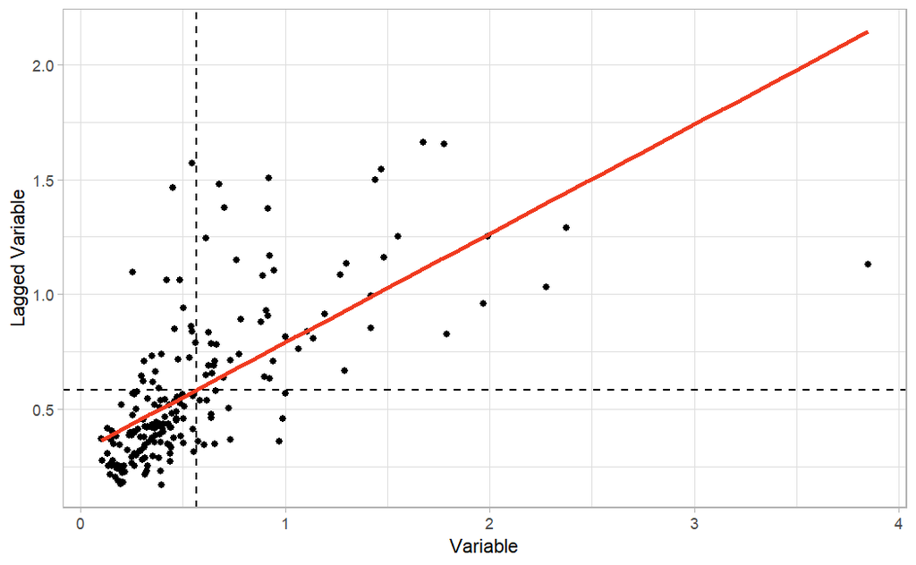

```r
ggplot() +
  geom_point(data = DataTemp, aes(x = Value, y = Lagged)) +
  geom_vline(xintercept = MeanValues, linetype = "dashed") +
  geom_hline(yintercept = MeanLagged, linetype = "dashed") +
  geom_smooth(data = DataTemp, aes(x = Value, y = Y_Est, method = "lm"),
              color = "#f03b20") +
  # scale_x_continuous(limits = c(0, 4)) +
  # scale_y_continuous(limits = c(0, 2)) +
  xlab("Variable") + ylab("Lagged Variable") +
  theme_light()
```

## 3.4 Geary index

function **geary.test()** from the *spdep* library

```r
geary.test(MexicoCity_HTS$CarTrips_PerPopulation, WM_)
```

```
    Geary C test under randomisation

data:  MexicoCity_HTS$CarTrips_PerPopulation
weights: WM_

Geary C statistic standard deviate = 6.6255, p-value = 1.73e-11
alternative hypothesis: Expectation greater than statistic
sample estimates:
Geary C statistic       Expectation          Variance
       0.59700354        1.00000000        0.00369967
```

# 4 LISA

## 4.1 Moran’s I

Most of the work is handled by the **localmoran()** function from the *spdep* library/

```r
MexicoCity_HTS$Variable <- MexicoCity_HTS$CarTrips_PerPopulation
ZonesAnalysis <- MexicoCity_HTS %>% select(Variable)
```

```r
Variable.lag <- lag.listw(WM_, ZonesAnalysis$Variable)

DataTemp <- data.frame(
  Lagged = Variable.lag,
  Value = ZonesAnalysis$Variable)

MeanValues = mean(DataTemp$Value)
MeanLagged = mean(DataTemp$Lagged)

Model_Y_Ylagged <- lm(Lagged ~ Value, data = DataTemp)

DataTemp$Y_Est <- predict.lm(Model_Y_Ylagged, DataTemp)
```

```r
LocalMoran_Temp <- localmoran(ZonesAnalysis$Variable, WM_)

LocalMoran_Temp <- as.data.frame(LocalMoran_Temp)
names(LocalMoran_Temp)[5] <- "PValue"

ZonesAnalysis %<>% bind_cols(LocalMoran_Temp)

ZonesAnalysis$Lagged <- lag.listw(WM_, ZonesAnalysis$Variable)
ZonesAnalysis$Value <- ZonesAnalysis$Variable

MeanValues = mean(ZonesAnalysis$Value)
MeanLagged = mean(ZonesAnalysis$Lagged)
MeanMoran = mean(ZonesAnalysis$Ii)

ZonesAnalysis %<>%
  mutate(
    Values_Centered = Value - MeanValues,
    Lagged_Centered = Lagged - MeanLagged,
    Moran_Centered = Ii - MeanMoran)

ZonesAnalysis %<>%
  mutate(Significance = if_else(PValue <= 0.05, 1, 0)) %>%
  mutate(Cuadrants = 5) %>%
  mutate(Cuadrants = if_else(Values_Centered > 0 & Lagged_Centered > 0, 1, Cuadrants)) %>%
  mutate(Cuadrants = if_else(Values_Centered > 0 & Lagged_Centered < 0, 2, Cuadrants)) %>%
  mutate(Cuadrants = if_else(Values_Centered < 0 & Lagged_Centered < 0, 3, Cuadrants)) %>%
  mutate(Cuadrants = if_else(Values_Centered < 0 & Lagged_Centered > 0, 4, Cuadrants)) %>%
  mutate(Cuadrants = if_else(Significance == 0, 5, Cuadrants))

# 1: High-High - Spatial clusters
# 2: High-Low - Outliers
# 3: Low-low - Spatial clusters
# 4: Low-High - Outliers
# 5: Not significance
# c("High-High", "High-Low", "Low-low", "Low-high", "Not significant")
ZonesAnalysis$Cuadrants <- factor(as.character(ZonesAnalysis$Cuadrants),
                                  levels = c("1", "2", "3", "4", "5"),
                                  ordered = TRUE)
```

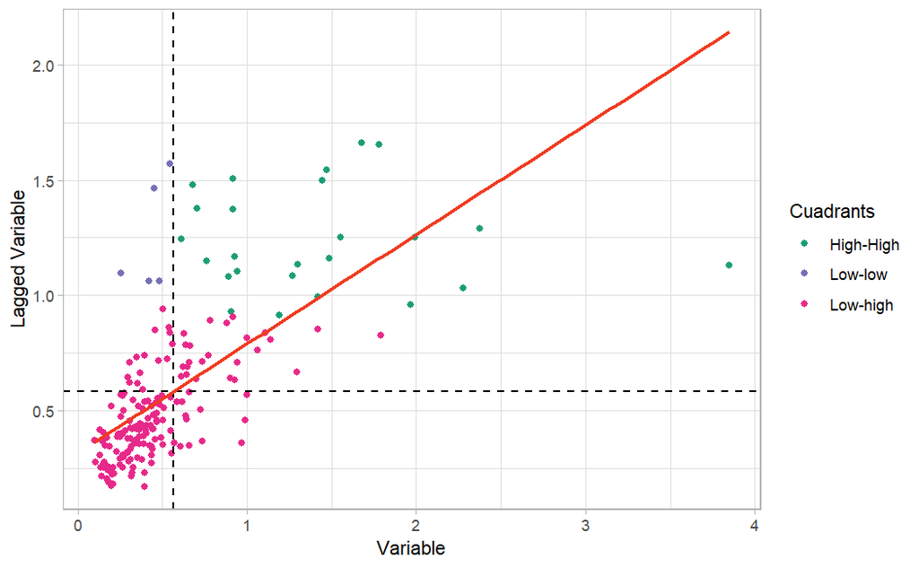

```r
ggplot() +
  geom_point(data = ZonesAnalysis, aes(x = Value, y = Lagged, color = Cuadrants)) +
  scale_color_manual(values = c("#1b9e77", "#7570b3", "#e7298a", "#d0d1e6"),
                    labels = c("High-High", "Low-low", "Low-high", "Not significant")) +
  geom_vline(xintercept = MeanValues, linetype = "dashed") +
  geom_hline(yintercept = MeanLagged, linetype = "dashed") +
  geom_smooth(data = DataTemp, aes(x = Value, y = Y_Est, method = "lm"),
              color = "#f03b20") +
  xlab("Variable") + ylab("Lagged Variable") +
  theme_light()
```

```r
Breaks <- c(0, 1.5, 2.5, 3.5, 4.5, 5.5)
Labels <- c("High-high (clusters)", "High-low",
            "Low-low (clusters)", "Low-high", "Not significant")
MyPalette <- c("#1b9e77", "#d95f02", "#7570b3", "#e7298a", "#edf8fb")
```

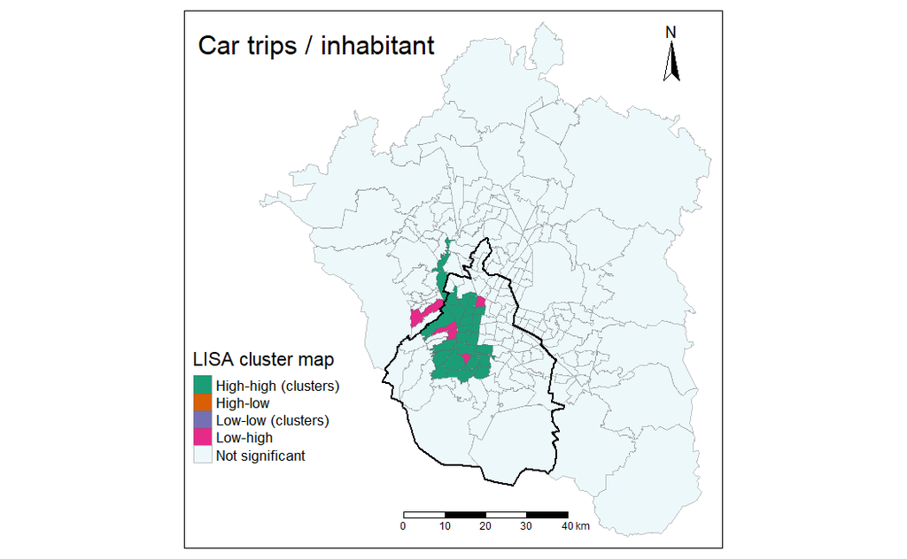

```r
Map_LISA <- tm_shape(ZonesAnalysis, bbox = BB_Districts) +
  tm_fill("Cuadrants",
           palette = MyPalette, breaks = Breaks, labels = Labels,
          title = "LISA cluster map") +
  tm_borders(alpha = 0.4) +
  tm_shape(MexicoCity_Fringe) +
  tm_polygons(alpha = 0, border.col = "black", lwd = 1.4, lty = "solid") +
  tm_compass(size = 2, type = "arrow", position = c(0.85,0.87)) +
  tm_scale_bar(position = c(0.4,0.02)) +
  tm_layout(title = "Car trips / inhabitant", legend.position = c(0.01,0.15), scale = 1)

Map_LISA
```

```r
tmap_save(tm = Map_LISA, filename = "Maps_LISA.jpeg",
          width = 2500, height = 2500)
```